# Part II - (Prosper Loan Dataset)

## by (Hillary Kipngeno)

## Investigation Overview

In this dataset i wanted to investigate the factors that affect the loanoriginalamount. I investigated variables like prosperscore, borrowers rate or interest rate, and loan term.

## Dataset Overview

This data set contains 113,937 loans with 81 variables on each loan, including loan amount, borrower rate (or interest rate), current loan status, borrower income, and many others.

## (Visualization 1)

> This is the distribution of term in months.In the term distribution, it occurs that many borrowers prefer to take a loan that is of a term of 36 months as compared to both a term of 60 and a term of 12months which is the least likely.

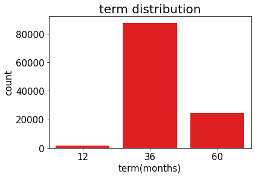

## (Visualization 2)

Comparison between prosperscore and loanoriginalamount. This shows that there is a positive relationship between loanoriginalamout and prosperscore. As the prosperscore increases the original loan amount increases too.This shows that there is a positive relationship between loanoriginalamout and prosperscore. As the prosperscore increases the original loan amount increases too.

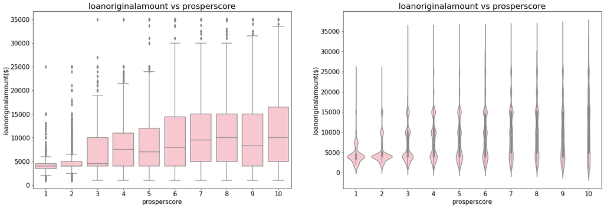

## (Visualization 3)

This is a comparison between borrowersrate and loanoriginalamount. There is a negative relationship between borrower rate and loan original amount. As the borrower rate increases the loan original loan amount decreases.

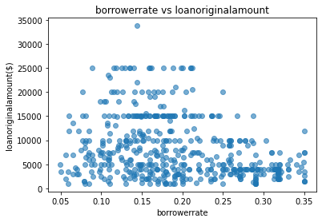